# Non-Linear Parametric Modeling in R using Genetic Algorithm

In solving a business problem, depending on the context of the problem, we may or may not be required to explain the predictions from a statistical model. When we need to understand and explain the predictions, we tend to use parametric or equation based models. When accuracy of prediction is all that matters, we prefer machine learning based models as these algorithms tend to have higher accuracy than parametric models for a given amount of invested effort. There are other advantages to using machine learning based models like ability to handle high dimensionality (Random Forest vs Linear Regression). With recent advancements through “interpretable machine learning” effort, we have also got partial dependency plots and shapely plots that mitigate “black-box” drawback of machine learning.

Inspite of such advantages to machine learning based models, when it comes to explainability of predictions, nothing works as good as an equation based model. Businesses tend to believe and buy into ideas that they can understand, interpret and fiddle with to see if its in line with what is expected. Apart from this, speaking from personal experience, equation based models are more reliable when they have to predict using data outside of training data range, and they react in a anticipated fashion in such scenarios. As such, we feel more confident about equation based models. But, [“no free lunch theorem”](https://en.wikipedia.org/wiki/No_free_lunch_theorem) might resonate with many of us and an individual’s call (“artistic bend”) to choose between either of the approaches (parametric or non-parametric) should be respected.

If you have decided to use the parametric or equation based approach, and the equation being fit to the data is not linear in nature, this article might be of help to you. Through this post, we will see how we can use Genetic Algorithm to fit non-linear equations to a dataset.

In our early career in data science, most of us must have seen and used linear regression. While practicing with linear regression, if an explanatory variable would have a non-linear trend with the dependent variable, we would try out different transformations (log(x), 1/x, x^2, etc.) to straighten out the non-linearity and use the transformed explanatory variable in modeling the dependent variable. In fitting many non-linear equations, this workaround can still be helpful. For example, if we are trying to fit
$$y = a*e^{b*x}$$
where a and b are being solved for, we can take log on both the sides and model the value of
$$log(y) = log(a) + b*x$$
In this, log(y) can treated as y1, log(a) can be treated as x1 and equation becomes
$$y1 = x1 + b*x$$
Using linear regression this can be solved and transformations can be reversed for solving a and b to get back original equation.

There are non-linear equations where we need to solve the them in their original form due to their complexity. There are also advantages like avoiding local minima that are part of the algorithms that we are going to discuss, which could offer a motivation to solve the equations in their original form. In this article, we will see how we can solve such equations using Genetic Algorithm.

We have heard that human population has increased exponentially over the last many centuries. Although [recent research](https://blog.ucsusa.org/doug-boucher/world-population-growth-exponential) suggests that it has started to become linear in last 50 odd years, for our problem we will consider it to be exponential and fit an exponential equation to the world population. The equation would be:
$$P = Po*e^{r*t}$$

We will be solving for “r” through GA

# Genetic Algorithm

Genetic algorithm belongs to the class of evolutionary computing algorithms. This algorithms mimics the process of evolution to perform optimization - creates a population of initial solutions, applies mutation, crossover, selection and other evolutionary functions to take out best solutions, then repeats the steps over generations/iterations till all the iterations are exhausted or no significant improvement is noticed. There are many good resources online to learn GA and interesting applications people have used it in. In its basic form, GA is an optimization algorithm and can be used in solving equations, traveling salesman problem, etc. What I appreciate about GA is that there are many parameters in it that you can manage and specify, all these helpful in avoiding local minima and finding a good solution.

We start with reading in the required libraries and dataset. Dataset has been downloaded from [here](https://ourworldindata.org/world-population-growth)

```r
libs <- c('GA', 'dplyr', 'ggplot2','doParallel')
lapply(libs, require, character.only = T)
```

```
## Package 'GA' version 3.2
```

```
## [[1]]
## [1] TRUE
##
## [[2]]
## [1] TRUE
##
## [[3]]
## [1] TRUE
##
## [[4]]
## [1] TRUE
```

```r
df <- read.csv("A:/Projects/Non-Linear Parametric Modelling/WorldPopulationAnnual12000years_interpolated_HYDEandUNto2015.csv", header = T, stringsAsFactors = F)
head(df)
```

```
##     year World.Population..Spline.Interpolation.until.1950.
## 1 -10000                                            2431214
## 2  -9999                                            2432196
## 3  -9998                                            2433179
## 4  -9997                                            2434162
## 5  -9996                                            2435145
## 6  -9995                                            2436129
```

```r
df <- df[(nrow(df)- 100):nrow(df),]
df$year <- df$year - min(df$year)
colnames(df)[1] <- "t"
colnames(df)[2] <- "P"
```

We now assign Po, which is the population in the first year of the dataset

```r
Po <- df$P[df$t == 0]
```

Let’s visualize how does the population growth looks like:

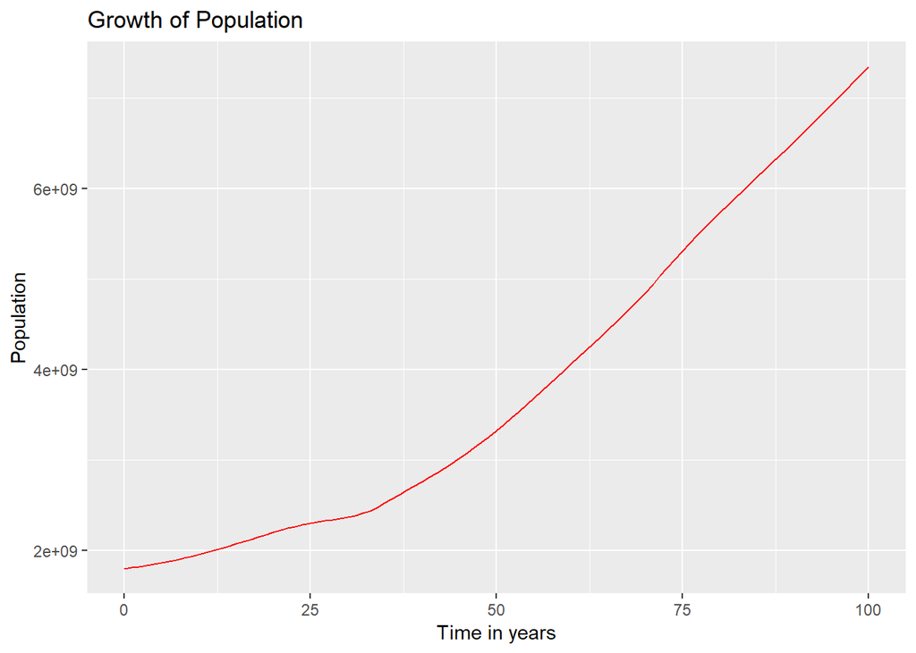

```r
ggplot2::ggplot(df, aes(t, P)) + geom_line(color = "red") + xlab("Time in years") + ylab("Population") + ggtitle("Growth of Population")
```

Well, the trend does appear to be exponential in the first half but seems to become linear in the second half. For our demonstration of demonstration of GA, we will continue to consider the curve to be exponential

There are four esstential steps in the process:  
1. Declare the name of the variable being solved for. This step ensures readability of the output from GA when many variables are being solved for.  
2. Defining the upper limit and lower limit of the search space in which solution of the variables will be looked for  
3. Defining the fitness function, using which GA will evaluate the quality of the solution - this is a critical step as it how accurate will the final solution (also, as it is user defined, generally beginners can get stuck here, key is to use as input all parameters used to calculate the error)  
4. Executing the GA iteration with all the parameters specified. This step is where we define how the GA will evolve solutions over generations

### We perform steps 1 to 3 here:

```r
gaNames <- "rate of growth of population" #declaring the name of the variable we are solving for

# Defining the fitness function, i.e., a function which will evaluate how close the actual values are to the output of the exponential function we have hypothesized for the population growth
fitnessFunction <- function(P, Po, r, t){
  Pfit <- Po*exp(r*t)
  error <- (P - Pfit)^2
  fitness <- -sum(error) # GA is a maximization function, as we want to reduce the error, we introduce a negative sign here
}

# We declare the search space, i.e. the space in which the values of r can be found. As we know that population has increased, r can only be a positive value. So lower limit of r will be 0. We do not know where exactly the upper limit of r will be, but as a good first guess, we will let it be 0.05 (5%)
upperLimitOfSearchSpace = 0.05 # These limits should be a vector of same length as gaNames and in same order as well, since we are defining the search space for all the unknowns
lowerLimitOfSearchSpace = 0.0001
```

### Next we initiate the GA to search for the solution:

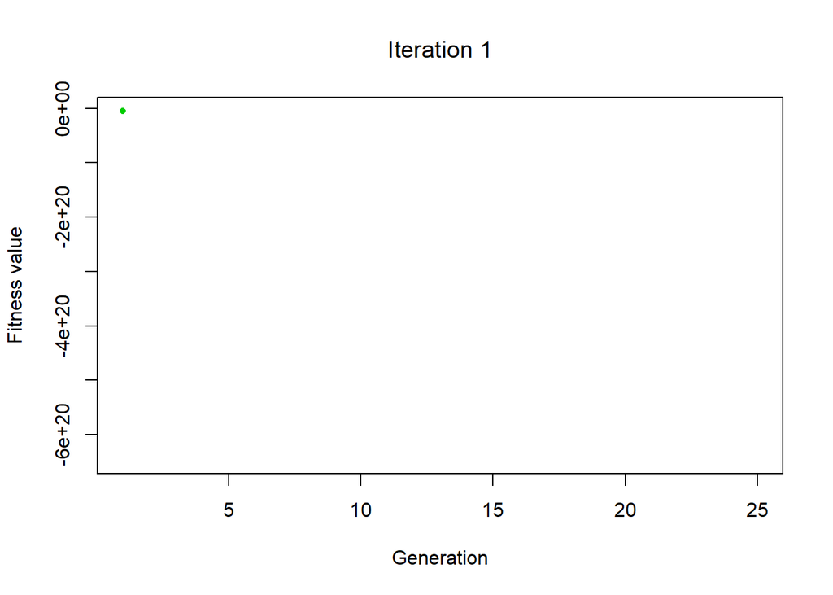

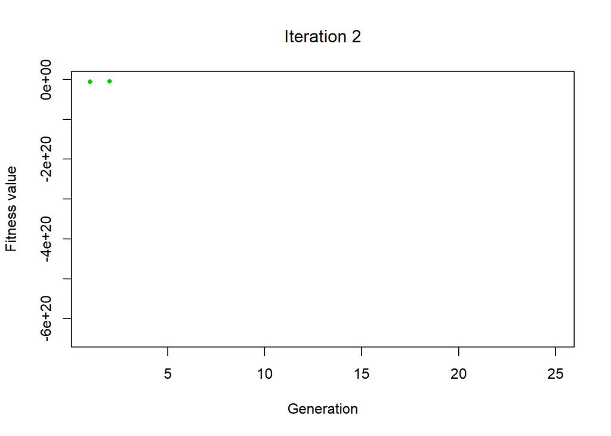

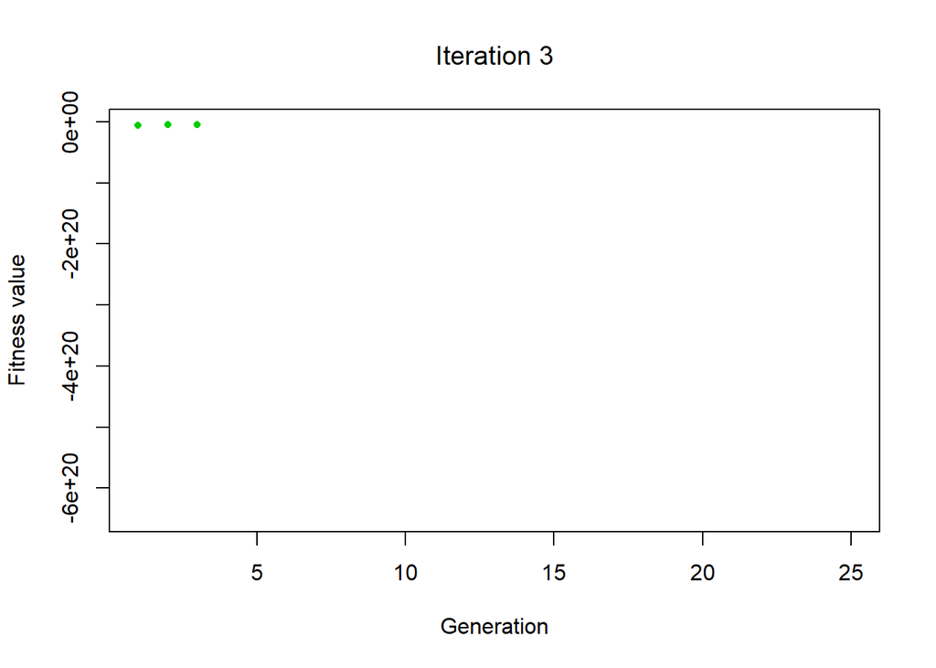

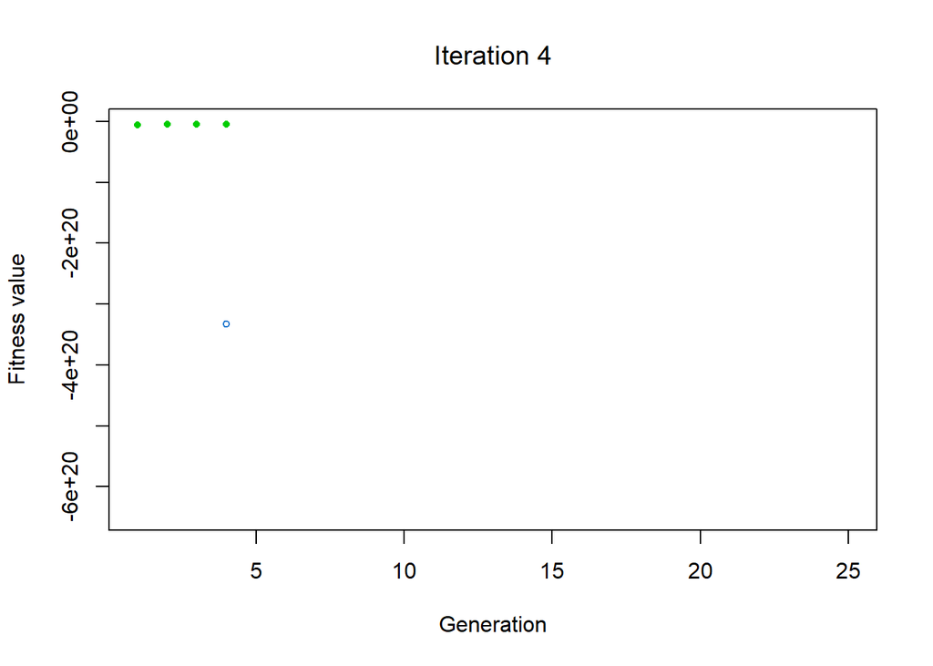

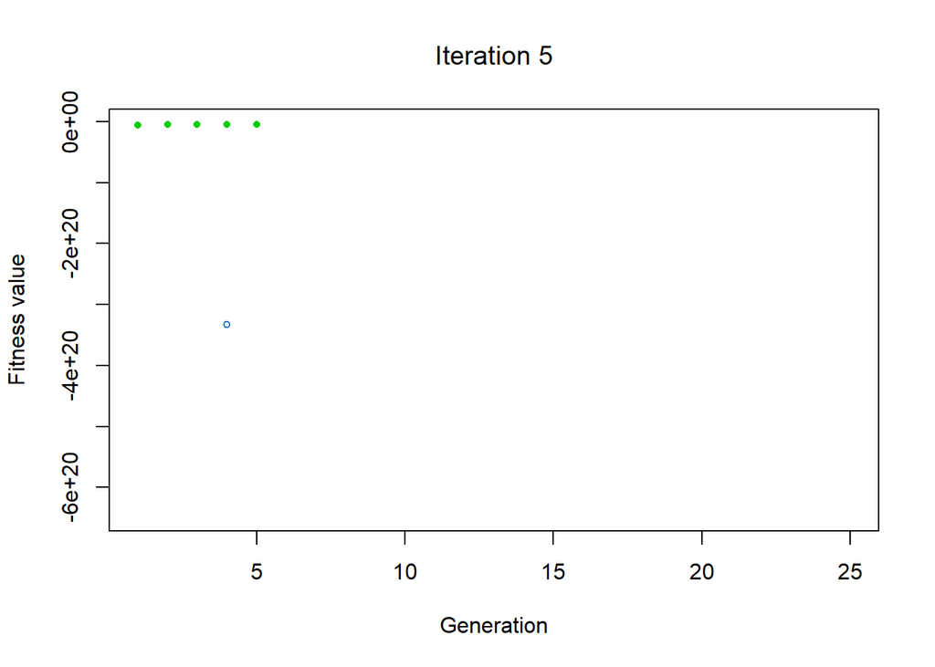

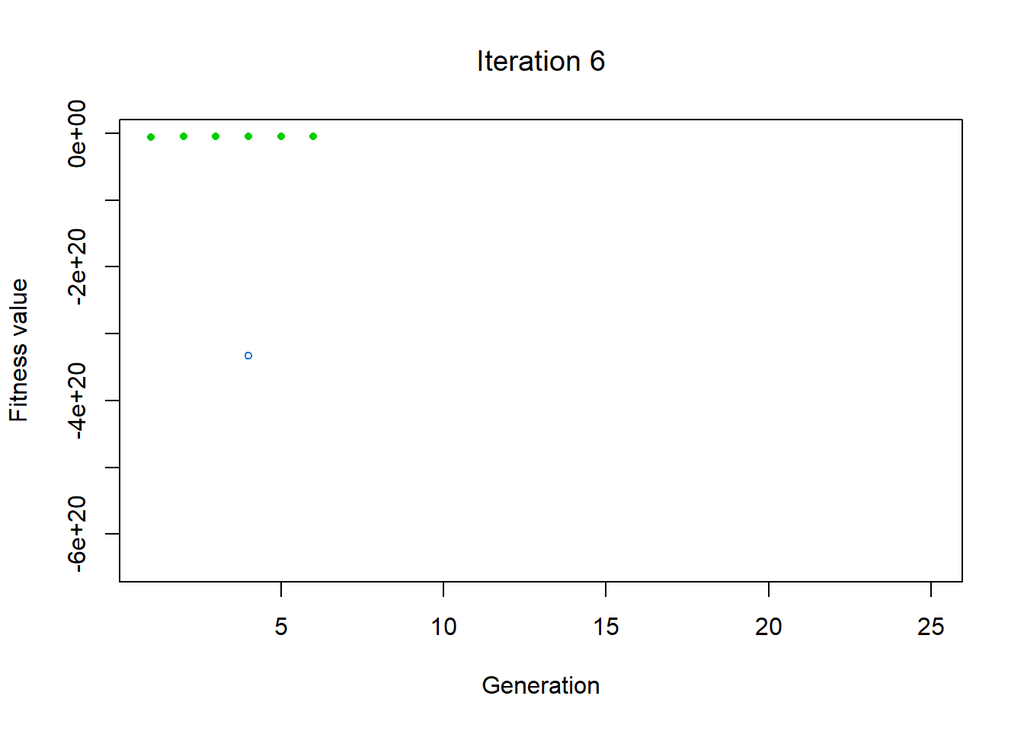

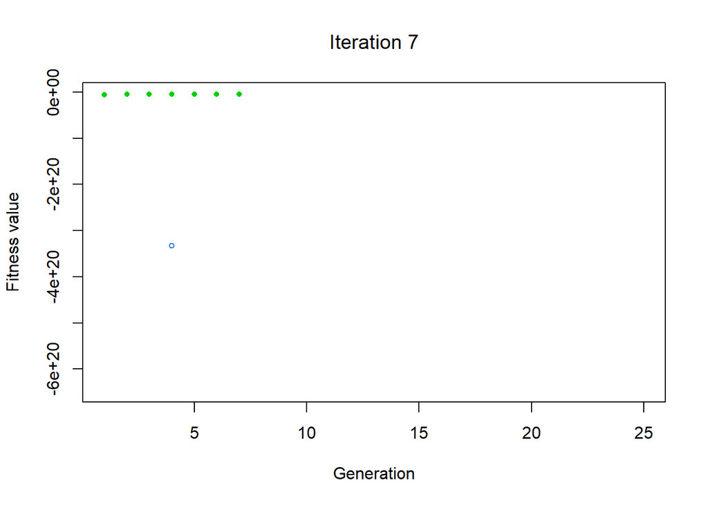

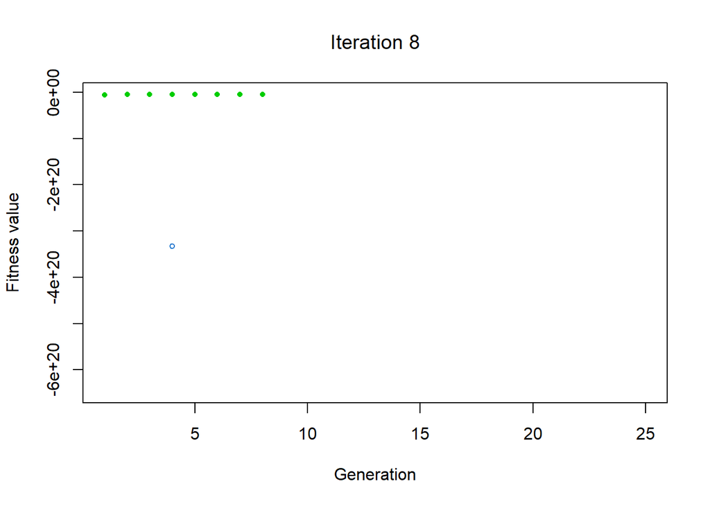

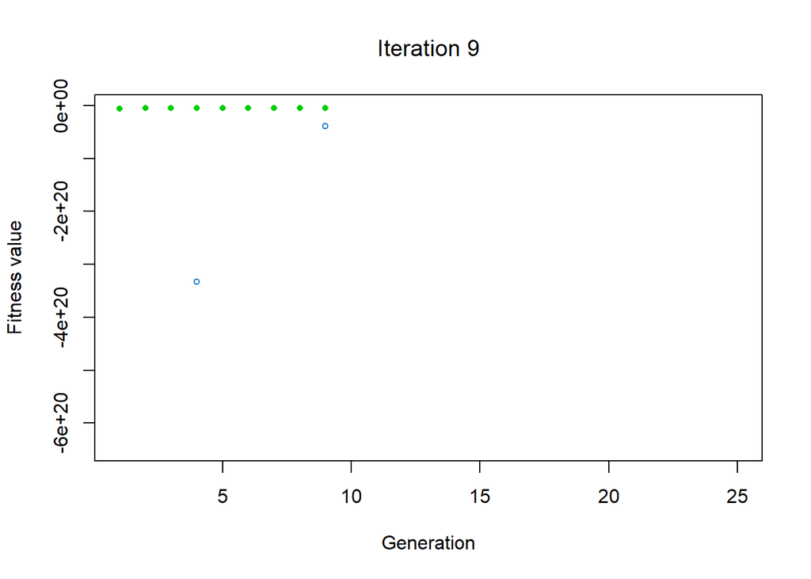

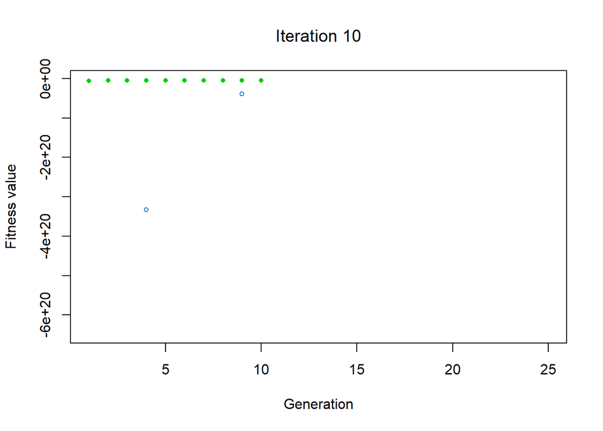

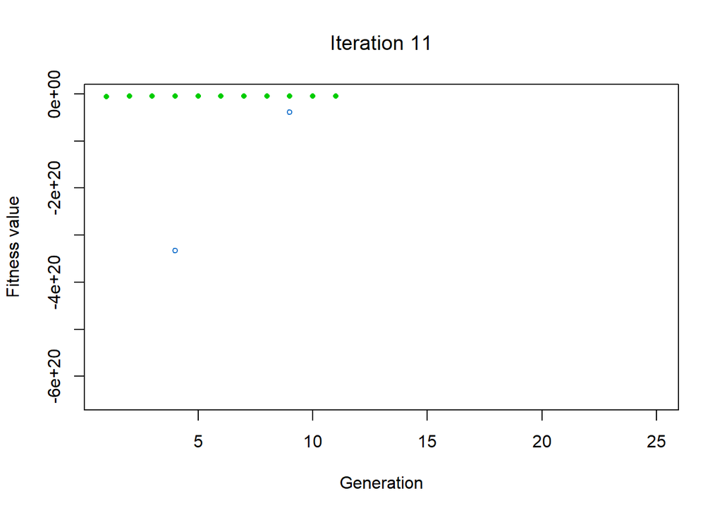

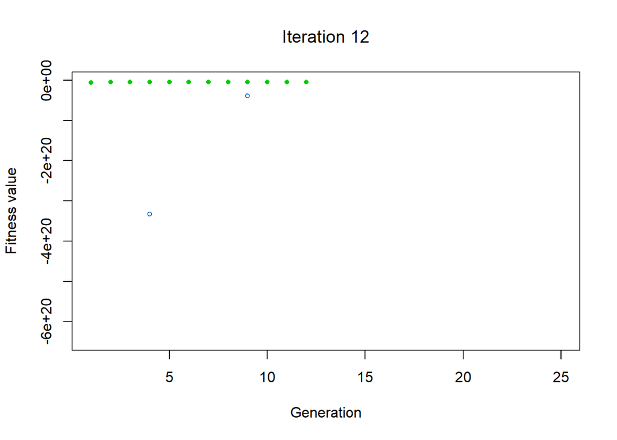

[13 more figures not shown]

```r
rGA <- ga( #the function is called as ga
  type = "real-valued", # solving for a real number, not rank or combination
  fitness = fitnessFunction, # passing the fitness function to evaluate quality of solution
  P = df$P, # We pass the variables needed to estimate the fitness function, which in our case are P, Po and t
  Po = df$P[df$t == 0],
  t = df$t,
  lower = lowerLimitOfSearchSpace,
  upper = upperLimitOfSearchSpace,
  pcrossover = 0.9, #crossover, mutation, etc. these are the paramterers that lend GA it's advantage of finding global optimum. These are intuitive to understand. These can be tuned to find a good solution
  pmutation = 0.10,
  elitism = 10,
  popSize = 50, # number of solutions in a generation to be evolved
  population = "gareal_Population",
  selection = "gareal_nlrSelection",
  crossover = "gareal_laCrossover",
  mutation = "gareal_nraMutation",
  maxiter = 25, # this specifies algorithm to evolve solution over 25 generations
  run = 20, # if no improvement over 10 generations, then stop further evolutions
  parallel = TRUE, # use multiple CPU cores for faster execution
  monitor = plot, # this plots the fitness from best solution and average fitness from all solution in a generation of solutions
  names = gaNames
)
```

```r
# Printing the best solution from the GA output
cat("\nBest value of rate of growth of population:",round(rGA@solution*100,2),"%\n")
```

```
##
## Best value of rate of growth of population: 1.41 %
```

### Let’s plot the population fit line

We notice here that we can closely fit an exponential line using the solution from GA to the actual population data

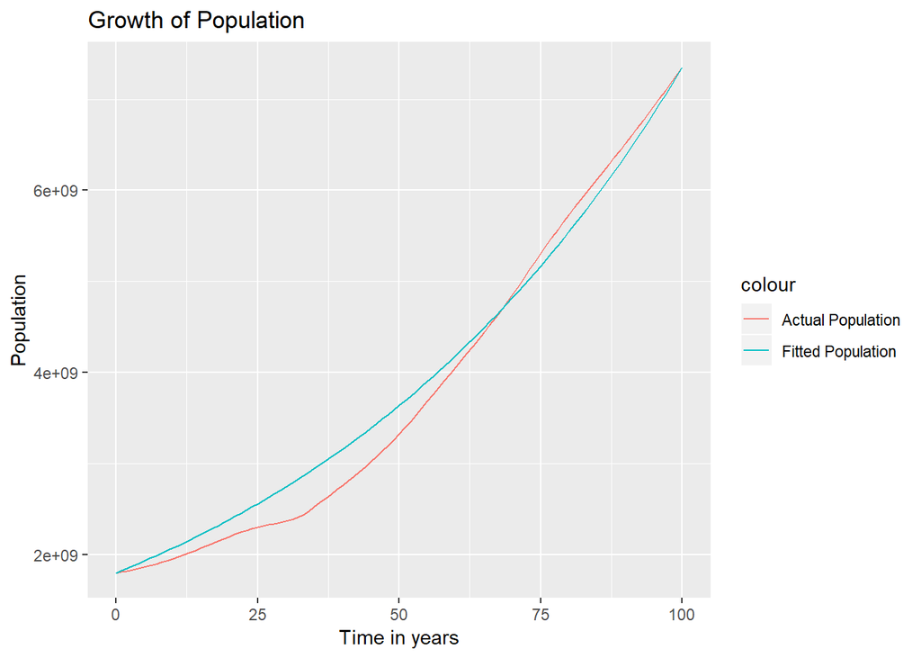

```r
df$pFit <- df$P[df$t == 0]*exp(as.numeric(rGA@solution)*df$t)
ggplot(df, aes(t)) +
  geom_line(aes(y = P, colour = "Actual Population")) +
  geom_line(aes(y = pFit, colour = "Fitted Population")) +
  xlab("Time in years") + ylab("Population") + ggtitle("Growth of Population")
```

In projects, we also look at other measures like RMSE, MAPE, etc. to determine how good our solution from GA fits the actual data.

### Closing Note:

We have seen how we can leverage an evolutionary computing algorithm like Genetic Algorithm to solve non-linear equations. There are many other algorithms in the same class: Ant Colony Optimization, Simulated Annealing, etc. These can also be used in similar manner for exploring solutions to equations.